# ¶ Assignment 7: Functions of functions: How the Doctors Got Their Scrips ¶

*Agenda*: Writing functions to automate jobs; applying functions; creating new variables.

#### INSTRUCTIONS:

- Type each one of the R commands in this lesson on the space provided below.
- You can embed an R code chunk like this:

  ```r
  summary(cars)
  ```

  ```
  ##      speed           dist
  ##  Min.   : 4.0   Min.   :  2.00
  ##  1st Qu.:12.0   1st Qu.: 26.00
  ##  Median :15.0   Median : 36.00
  ##  Mean   :15.4   Mean   : 42.98
  ##  3rd Qu.:19.0   3rd Qu.: 56.00
  ##  Max.   :25.0   Max.   :120.00
  ```

- Before you move to the next step, highlight or move the cursor to the end of the individual R command and click on **Run**. Do this for all R commands.
- After you are done click the **Knit HTML**, **Knit PDF** button (upper left window). A document will be generated that includes both content as well as the output of any embedded R code chunks within the document.
- Go to File –> Save. Name your file.
- Upload the file to the Moodle site by using the link provided.

In the Assignment 5, we worked with one of the classic data sets on the diffusion of innvoations, on the spread of the use of tetracycline among doctors in Illinois in the 1950s. We wrote R expressions to find things like how many of doctor 37’s friends had begun prescribing tetracycline by month 5. In this lab, we will turn those particular expressions into general functions, and apply them across the data, to get systematic evidence about whether new practices can spread by peer pressure.

Under Assignment 5 you will see two links that are labed Data file for Assignment 5. If you did not do it before, click on each download the files and upload to RStudio.As a reminder, “ckm_nodes.csv”” has information about each individual doctor in the four towns.”ckm_network.dat” are the records which doctors knew each other.

# Part I

##### Problem 1. (10 points)

Load the dataset ckm_nodes.csv into a data frame, ckm_nodes. The adoption_date column records the month in which the doctor began prescribing tetracycline, counting from November 1953. If the doctor did not begin prescribing it by month 17, i.e., February 1955, when the study ended, this is recorded as Inf. If it’s not known when or if a doctor adopted tetracycline, their value is NA. Create a vector which records the index numbers of doctors for whom adoption_date is not NA. Check that this vector has length 125. Create a data frame, cleaned_nodes, which contains only those rows of ckm_nodes. (Do not drop rows if they have a value for adoption_date but are NA in some other column.) Use cleaned_nodes, rather than ckm_nodes, for the rest of the assignment.

##### Solution

Type your answer here

```r
ckm_nodes = read.csv("ckm_nodes.csv")
cleaned_nodes = na.omit(ckm_nodes$adoption_date)
length(cleaned_nodes)
```

```
## [1] 125
```

```r
sum(is.na(cleaned_nodes))
```

```
## [1] 0
```

##### Problem 2. (10 points)

Write a function, adopters, which takes two arguments, month, with no default value, and not.yet, defaulting to FALSE. If not.yet is FALSE, adopters should return a Boolean vector, indicating the doctors who began prescribing tetracycline in that month. If not.yet is TRUE, then adopters should return the vector indicating the doctors who began prescribing after that month (or never did). Check that adopters(2) indicates 9 doctors began prescribing in month 2, and that adopters(month=14,not.yet=TRUE) indicates that 23 doctors began prescribing after month 14, or never did.

##### Solution

Type your answer here

```r
adopters = function(month, not.yet = FALSE){
  if(not.yet){
    return(cleaned_nodes > month)
  } else {
    return(cleaned_nodes == month)
  }
}
sum(adopters(2))
```

```
## [1] 9
```

```r
sum(adopters(month = 14, not.yet = TRUE))
```

```
## [1] 23
```

##### Problem 3. (10 points)

The file ckm_network.dat contains a binary matrix; the entry in row i, column j is 1 if doctor number i said that doctor j was a friend or close professional contact, and 0 otherwise. Load the file into R as ckm_network, and verify that gives you a square matrix which contains only 0s and 1s, and that it has 246 rows and columns. Create a new matrix, clean_network, which drops the the rows and columns corresponding to doctors with missing adoption_date values. Check that the result has 125 rows and columns. Use this reduced matrix, and its row and column numbers, for the rest of the assignment.

##### Solution

Type your answer here

```r
ckm_network = as.matrix(read.table("ckm_network.dat"))
sum(ckm_network > 1)
```

```
## [1] 0
```

```r
nrow(ckm_network)
```

```
## [1] 246
```

```r
ncol(ckm_network)
```

```
## [1] 246
```

```r
ckm_nodes <- read.csv("ckm_nodes.csv")
non_na_indices <- which(!is.na(ckm_nodes$adoption_date))
cleaned_network <- ckm_network[non_na_indices, non_na_indices]
dim(cleaned_network)
```

```
## [1] 125 125
```

##### Problem 4. (10 points)

Create a vector which stores the number of contacts each doctor has. Do not use a loop. Check that doctor number 41 had 3 contacts.

##### Solution

Type your answer here

```r
rowSums(cleaned_network)[41]
```

```
## [1] 3
```

# Part II

##### Problem 5. (10 points)

Counting Peer Pressure

1. Write a function, count_peer_pressure, which takes in the index number of a doctor and a month, and returns the number of doctors whom that doctor named as contacts, and had begun prescribing tetracycline by that month or earlier. If it is working properly, doctor number 37 and month 5 should return 3.

##### Solution

Type your answer here

```r
count_peer_pressure = function(doctor_index, month) {

  doctor_contacts = cleaned_network[doctor_index, ]

  prescribe_month = cleaned_nodes <= month
  peer_pressure = sum(doctor_contacts & prescribe_month)
  return(peer_pressure)
}


count_peer_pressure(37, 5)
```

```
## [1] 3
```

2. Write a function, prop_peer_pressure, which takes in the index number of a doctor and a month, and returns the proportion of the doctor’s contacts who are already prescribing tetracycline by that month. If a doctor has no contacts, your function should return NaN. Check that doctor 37, month 5 returns a proportion of 0.6, but doctor 102 in month 14 returns NaN. Your function should call, not repeat, your function from (5a), and use your vector from (4).

##### Solution

Type your answer here

```r
prop_peer_pressure = function(doctor_index, month){
  total_contracts = rowSums(cleaned_network)[doctor_index]
  if(total_contracts == 0){
    return(NaN)
  }
  prescribing_contacts = count_peer_pressure(doctor_index, month)
  return(prescribing_contacts / total_contracts)
}
prop_peer_pressure(37, 5)
```

```
## [1] 0.6
```

```r
prop_peer_pressure(102, 14)
```

```
## [1] NaN
```

##### Problem 6. (10 points)

Averaging Peer Pressure

1. Write a function which takes in a month, and returns a vector of length two. The first element of the returned value should be the average proportion of prescribers among contacts of doctors who began prescribing in that month. The other should be the average proportion of prescribers among contacts of doctors who began prescribing later, or never. Call your code from (2) and (5); avoid using a loop if at all possible. Hint: mean has an na.rm option.

##### Solution

Type your answer here

```r
average_peer_pressure = function(month) {
  doctors_prescribed_in_month = cleaned_nodes == month

  never_prescribed = cleaned_nodes > month

  avg_prescribers_in_month = mean(sapply(which(doctors_prescribed_in_month),
  function(i) prop_peer_pressure(i, month)), na.rm = TRUE)

  avg_never_prescriber = mean(sapply(which(never_prescribed),
  function(i) prop_peer_pressure(i, month)), na.rm = TRUE)

  return(c(avg_prescribers_in_month, avg_never_prescriber))
}


average_peer_pressure(5)
```

```
## [1] 0.2698052 0.5258220
```

2. Plot the two average proportions from (6a) over time. Do not use a loop if you can help it. Do the doctors who adopt in a given month consistently have more contacts who are already prescribing than the non-adopters?

##### Solution

Type your answer here

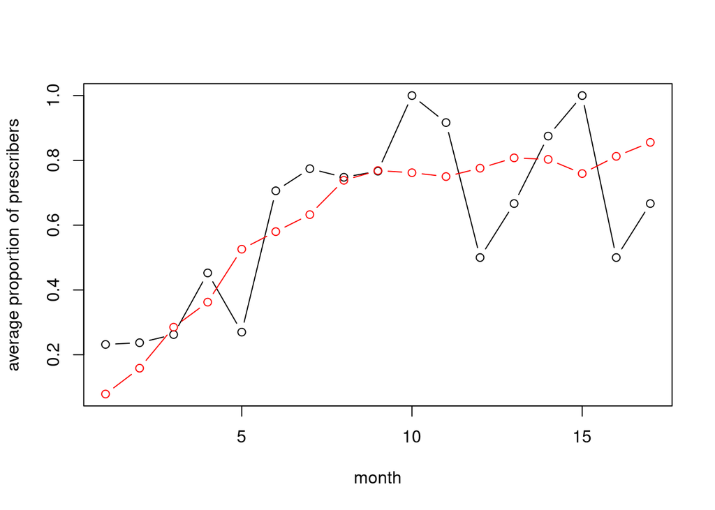

```r
max_month = max(cleaned_nodes[cleaned_nodes != Inf], na.rm = TRUE)
average_proportions = sapply(1:max_month, function(m) average_peer_pressure(m))

plot(1:max_month, average_proportions[1, ], xlab = "month", ylab = "average proportion of prescribers", ylim = range(average_proportions), type = "b")
lines(1:max_month, average_proportions[2, ], type = "b", col = "red")
```

```r
#it seems that the doctors who adopt in a given month do not consistently have more contacts who are already prescribing compared to the Non Adopters.
```